# Cell Count Analysis

AS Huffmyer

Script to analyze symbiont density for the Mcap 2021 Symbiont Integration project.

# **Setup**

Set up workspace, set options, and load required packages.

```r
knitr::opts_chunk$set(echo = TRUE, warning = FALSE, message = FALSE)
```

# **Symbiont Density**

Import and manipulate data

```r
# Cell count data
sym_counts <- read.csv("Mcap2021/Data/Cells/cell_counts.csv")
```

Calculate cells and normalize to total protein.

```r
# Calculate mean counts for each sample
df <- sym_counts %>%
  dplyr::select(TubeID, Squares_counted, Sample.ID, matches("Count[1-6]")) %>%
  gather("rep", "count", -TubeID, -Squares_counted, -Sample.ID) %>%
  group_by(TubeID, Squares_counted, Sample.ID) %>%
  dplyr::summarise(mean_count = mean(count, na.rm = TRUE))


#Load in total volume of sample
volumes<-read.csv("Mcap2021/Data/Resuspension_volumes.csv")
volumes<-dplyr::rename(volumes, TubeID=Tube.ID)

df<-left_join(df, volumes)

# Normalize counts by homogenate volume (ul)
df <- df %>%
  mutate(cells.mL = (mean_count * 10000) / Squares_counted,
         cells = cells.mL * (Resuspension_volume/1000))
```

This generated the total number of cells in each tube.

Now normalized to total protein.

First, calculate protein per uL from the “Holo” tube for each sample.

```r
protein<-read.csv("Mcap2021/Output/Protein/protein_output.csv")

protein<-protein%>%
  dplyr::rename(TubeID=Tube.ID)

protein<-left_join(protein, volumes)

protein$protein.ug.uL<-protein$Protein.ug/protein$Resuspension_volume

protein<-protein%>%
  filter(Fraction=="Holobiont")
```

Second, divide the total number of cells by the resuspension volume to obtain cells per uL

```r
df$cells.uL=df$cells/df$Resuspension_volume
```

Third, normalize cells per uL / protein per uL to obtain cells per ug protein

```r
all<-left_join(df, protein, by="Sample.ID")

all$cells.ugprotein=all$cells.uL/all$protein.ug.uL
```

Output data frame.

```r
all%>%
  dplyr::select(TubeID.x, Sample.ID, cells, cells.uL, cells.ugprotein, Resuspension_volume.x, Treatment)%>%
  dplyr::rename(Tube.ID=TubeID.x, Resuspension_volume=Resuspension_volume.x)%>%
  write_csv("Mcap2021/Output/Cells/cells_output.csv")
```

### Plotting

Plot cells per unit protein data with mean and standard error.

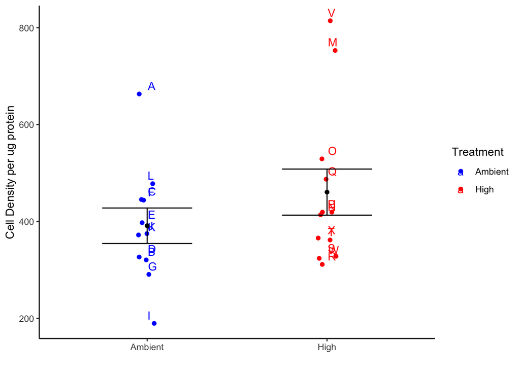

```r
all %>%
  filter(!Sample.ID=="H")%>%
  ggplot(aes(x = Treatment, y = cells.ugprotein, color = Treatment)) +
  labs(x = "",y = "Cell Density per ug protein") +
  scale_color_manual(values=c("blue", "red"))+
  geom_jitter(width = 0.05) +                                            # Plot all points
  geom_text(aes(label=Sample.ID), vjust = -0.5, hjust=-0.1)+
  stat_summary(fun.data = mean_cl_normal, fun.args = list(mult = 1),    # Plot standard error
               geom = "errorbar", color = "black", width = 0.5) +
  stat_summary(fun = mean, geom = "point", color = "black") + # Plot mean
  theme_classic()
```

Present means and standard error of each group and save summary table.

```r
all%>%
  group_by(Treatment)%>%
    filter(!Sample.ID=="H")%>%
  summarise(n=length(cells.ugprotein),
            Mean=format(round(mean(cells.ugprotein), 0), 0),
            SE=format(round(sd(cells.ugprotein)/sqrt(length(cells.ugprotein)),0),0))%>%
  kbl(caption="Descriptive statistics of Symbiodiniaceae cell densities")%>%
  kable_classic(full_width=FALSE, html_font="Arial")%>%
  row_spec(0, bold = TRUE)
```

Descriptive statistics of Symbiodiniaceae cell densities

| Treatment | n | Mean | SE |
| --- | --- | --- | --- |
| Ambient | 11 | 391 | 37 |
| High | 12 | 461 | 48 |

Plot data as a scatterplot with labels for each sample.

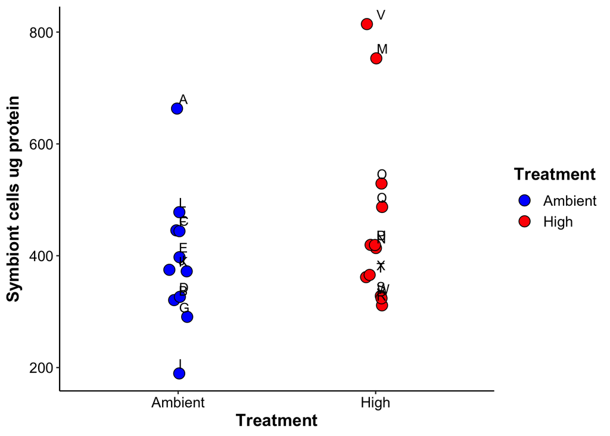

```r
symb_plot<-all %>%
    filter(!Sample.ID=="H")%>%
    droplevels()%>%
    ggplot(., aes(x = as.factor(Treatment), y = cells.ugprotein)) +
    geom_point(aes(fill=Treatment, group=Treatment), pch = 21, size=4, position = position_jitterdodge(0.1)) +
    geom_text(aes(label=Sample.ID), vjust = -0.5, hjust=-0.1)+
    xlab("Treatment") +
   scale_fill_manual(values=c("blue", "red"))+
    scale_color_manual(values=c("blue", "red"))+
    ylab(expression(bold(paste("Symbiont cells ug protein"))))+
    theme_classic() +
    theme(
      legend.position="right",
      axis.title=element_text(face="bold", size=14),
      axis.text=element_text(size=12, color="black"),
      legend.title=element_text(face="bold", size=14),
      legend.text=element_text(size=12)
      ); symb_plot
```

Plot data as box plot

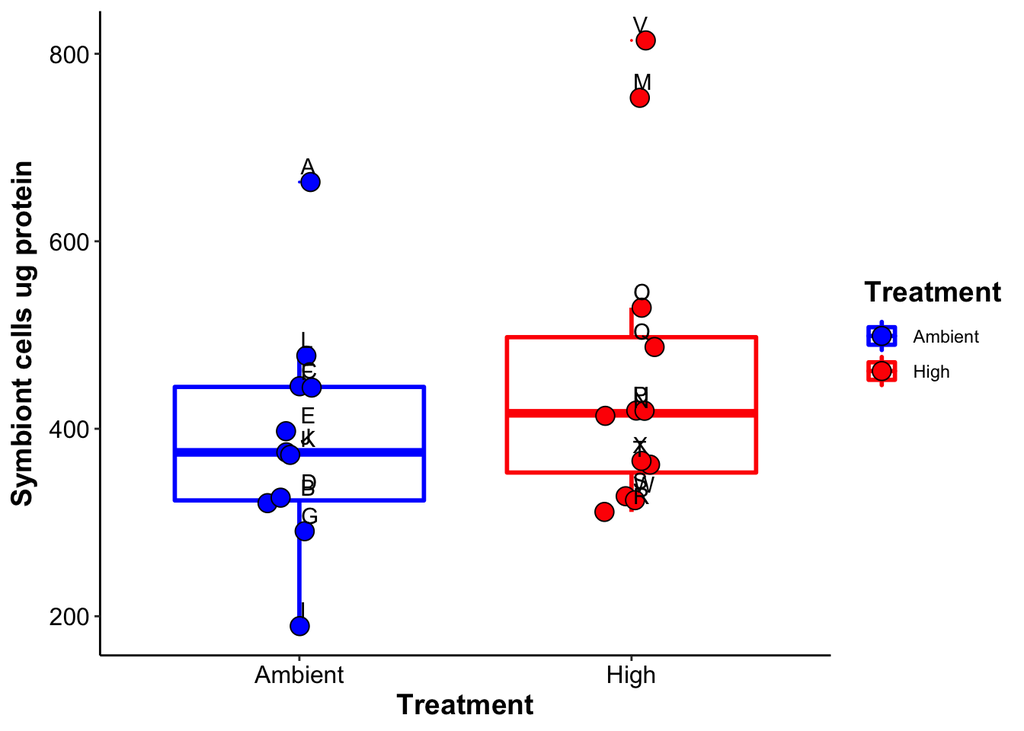

```r
symb_plot2<-all %>%
    filter(!Sample.ID=="H")%>%
    ggplot(., aes(x = as.factor(Treatment), y = cells.ugprotein)) +
    geom_boxplot(aes(color=Treatment), outlier.size = 0, lwd=1) +
    geom_point(aes(fill=Treatment), pch = 21, size=4, position = position_jitterdodge(0.2)) +
    scale_fill_manual(values=c("blue", "red"))+
  scale_color_manual(values=c("blue", "red"))+
    geom_text(aes(label=Sample.ID), vjust = -0.5, hjust=-0.1)+
    xlab("Treatment") +
    ylab(expression(bold(paste("Symbiont cells ug protein"))))+
    theme_classic() +
    theme(
      legend.position="right",
      axis.title=element_text(face="bold", size=14),
      axis.text=element_text(size=12, color="black"),
      legend.title=element_text(face="bold", size=14)
      ); symb_plot2
```

Plot symbiont density with plot and error bars.

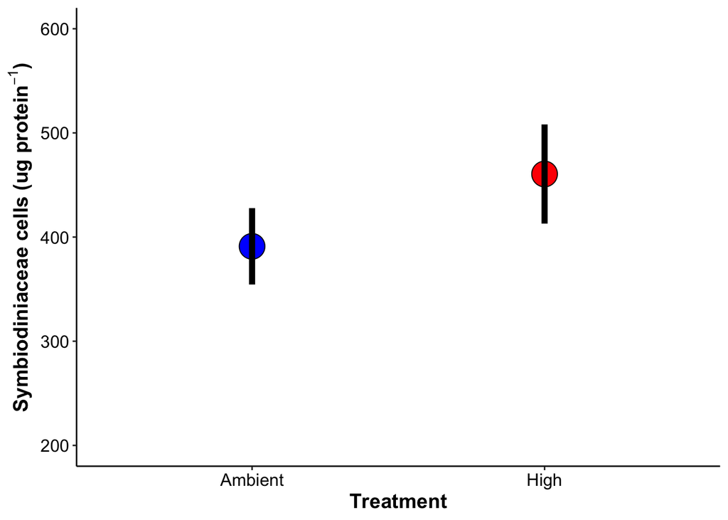

```r
symb_plot2_b<-all %>%
    filter(!Sample.ID=="H")%>%
    dplyr::group_by(Treatment)%>%
    dplyr::summarise(mean=mean(cells.ugprotein), se=sd(cells.ugprotein)/sqrt(length(cells.ugprotein)))%>%


    ggplot(., aes(x = as.factor(Treatment), y = mean)) +
    geom_point(aes(fill=Treatment), pch = 21, size=8) +
    geom_errorbar(aes(ymin=mean-se, ymax=mean+se, group=Treatment), pch = 21, size=2, width=0) +
    scale_fill_manual(values=c("blue", "red"))+
    scale_color_manual(values=c("blue", "red"))+
    xlab("Treatment") +
    ylim(200, 600)+
    ylab(expression(bold(paste("Symbiodiniaceae cells (ug protein"^-1, ")"))))+
    theme_classic() +
    theme(
      legend.position="none",
      axis.title=element_text(face="bold", size=14),
      axis.text=element_text(size=12, color="black"),
      legend.title=element_text(face="bold", size=14)
      ); symb_plot2_b
```

```r
#Save plot
ggsave(symb_plot2_b, file="Mcap2021/Figures/symbiont_density.png", w=4, h=4)
```

### Statistical analysis

Run ANOVA on cells per protein treatment.

```r
sym_model_data<-all%>%
      filter(!Sample.ID=="H")%>%
      droplevels()

sym_model<-aov(cells.ugprotein~Treatment, data=sym_model_data)
summary(sym_model)
```

```
##             Df Sum Sq Mean Sq F value Pr(>F)
## Treatment    1  27680   27680   1.301  0.267
## Residuals   21 446827   21277
```

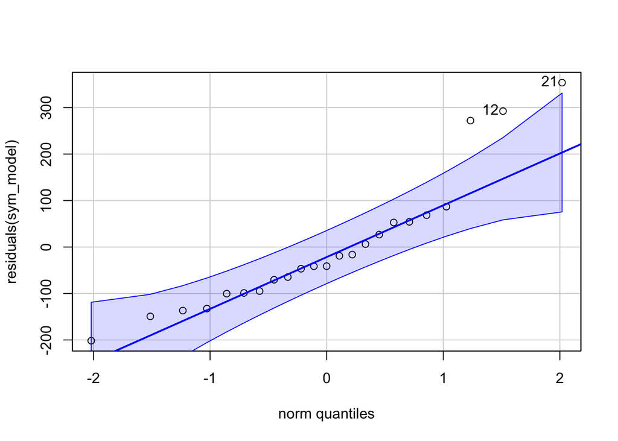

```
## [1] 21 12
```

```r
qqPlot(residuals(sym_model))
```

```r
leveneTest(residuals(sym_model)~Treatment, data=sym_model_data)
```

```
## Levene's Test for Homogeneity of Variance (center = median)
##       Df F value Pr(>F)
## group  1  0.3118 0.5825
##       21
```

No significant difference.